# Heatmap IL2 vs IL21

Dan Griffiths

2023-09-09

## Load libraries

```r
library(limma)
library(Glimma)
library(edgeR)
library(tidyverse)
library(DESeq2)
library(org.Hs.eg.db)
library(pheatmap)
library(EnhancedVolcano)
library(ComplexHeatmap)
```

```r
set.seed(42) # set seed for reproducibility in clustering
```

## 1 - Import counts

### 1.1 Import raw counts, coldata

```
## [1] TRUE
```

```r
counts <- as.data.frame(entrez.counts)
genes <- rownames(counts)
df <- as.data.frame(genes)
df$symbol <- mapIds(org.Hs.eg.db,genes,keytype = "ENSEMBL",column="SYMBOL")
mapped <- df$symbol
counts$symbol <- mapped
unique.mapped <- unique(mapped)
mapped <- na.omit(mapped)
diff <- setdiff(counts$symbol, mapped)
counts <- counts[!counts$symbol %in% diff, ]
counts <- counts[!duplicated(counts$symbol), ]
rownames(counts) <- counts$symbol
counts <- counts %>% dplyr::select(-c('symbol')) %>% as.matrix()
# now to filter for only protein-coding genes
genes <- rownames(counts)
df <- as.data.frame(genes)
df$desc <- mapIds(org.Hs.eg.db,genes,keytype = "SYMBOL",column="GENETYPE")
list.protein.coding <- which(df$desc == "protein-coding")
counts <- counts[list.protein.coding,]
counts <- counts %>% as.matrix()
# list.conds <- coldata$sample[which(coldata$condition %in% c("IL2","IL21"))]
# counts <- counts[,list.conds]
# coldata <- coldata %>% dplyr::filter(sample %in% list.conds)

# list.conds <- coldata$sample[which(coldata$healthy_donor %in% c("D1","D2"))]
# counts <- counts[,list.conds]
# coldata <- coldata %>% dplyr::filter(sample %in% list.conds)
```

### 1.3 heatmap with all variance, all conditions

```r
dds <- DESeqDataSetFromMatrix(counts,coldata, design =~condition)
smallestGroupSize <- 3
keep <- rowSums(counts(dds) >= 10) >= smallestGroupSize
dds <- dds[keep,]
dds <- DESeq(dds)
resultsNames(dds)
```

```
## [1] "Intercept"              "condition_IL2_vs_IL15"  "condition_IL21_vs_IL15"
## [4] "condition_IL7_vs_IL15"  "condition_UST_vs_IL15"
```

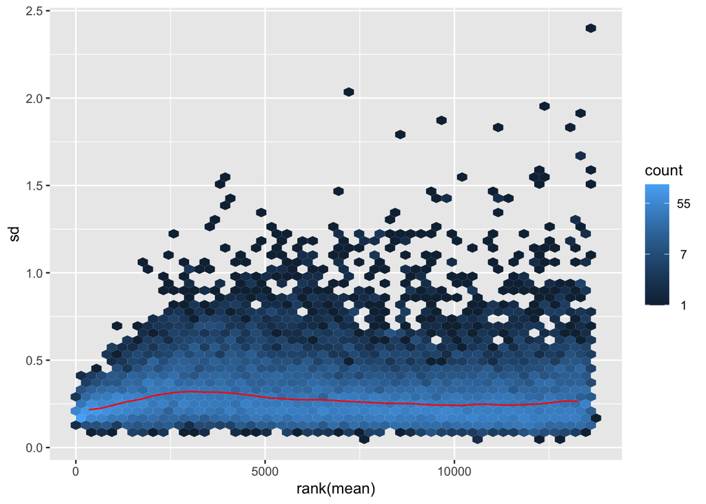

```r
res <- results(dds,contrast = c("condition","IL2","IL21"))
vst <- varianceStabilizingTransformation(dds)
vsn::meanSdPlot(assay(vst))
```

### 1.4 all variance heatmap plot

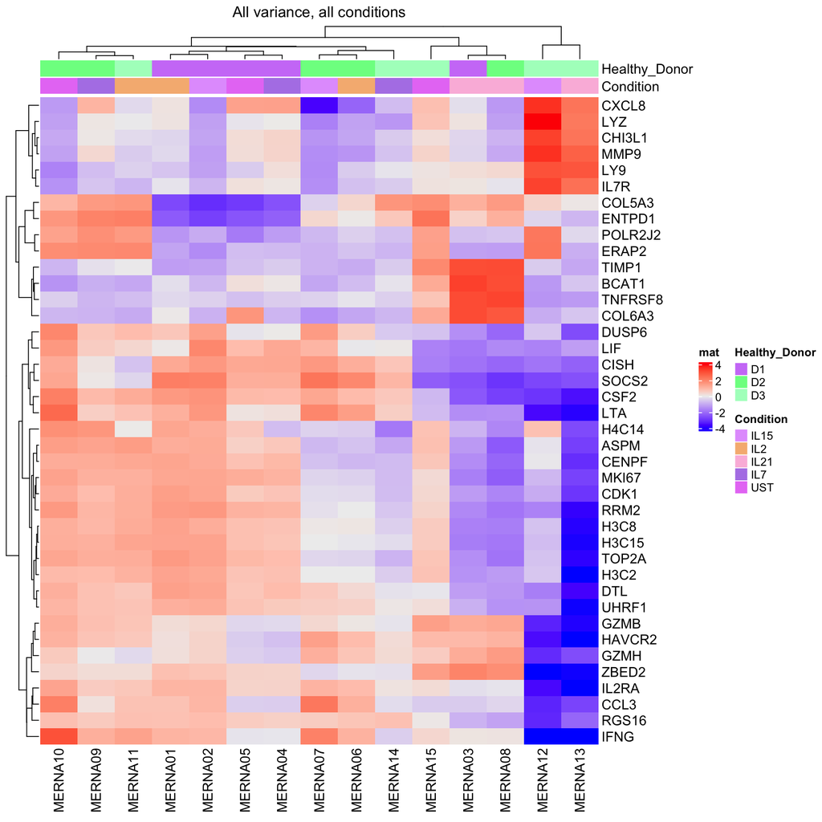

```r
topVarGenes <- order(rowVars(assay(vst)), decreasing = TRUE)
mat  <- assay(vst)[ topVarGenes[1:40], ]
mat  <- mat - rowMeans(mat)
anno <- coldata
column_ha = HeatmapAnnotation(Healthy_Donor = anno$healthy_donor, Condition = anno$condition)
Heatmap(mat,name = "mat",
        column_title = "All variance, all conditions",
        top_annotation = column_ha,
        cluster_columns = TRUE,
        cluster_rows = TRUE #,
        #column_split = anno$healthy_donor
        )
```

We want to find more appropriate genes for analysis, and although the above heatmap gives an hollistic view of the data, it is not useful for any further downstream analysis.

Therefore we can - Conduct a pairwise comparison of IL2 vs IL21 to find statistically significant genes, with the most polarised log-fold change. - Taking this genes with most extreme log-fold change, and plot variance of these genes in the following situations: a) plot relative variance in statistically significant genes in all conditions b) plot relative variance in statistically significant genes for IL2 and IL21 conditions only

## 2 - Make pairwise comparison, IL2vsIL21

### 2.1 Pairwise comparison table

Get list of genes that are LFC and p-value significant in comparison of IL2vsIL21

```r
resSig <- subset(res, padj < 0.1)
lfc <- resSig[ order(resSig$log2FoldChange, decreasing=TRUE), ]
lfc
```

```
## log2 fold change (MLE): condition IL2 vs IL21
## Wald test p-value: condition IL2 vs IL21
## DataFrame with 1003 rows and 6 columns
##               baseMean log2FoldChange     lfcSE      stat      pvalue
##              <numeric>      <numeric> <numeric> <numeric>   <numeric>
## NPIPA8        142.1690       23.36161   3.92866   5.94646 2.74006e-09
## TBC1D3C        38.2409       22.25217   4.68429   4.75038 2.03031e-06
## TBC1D3F        34.4205       21.37384   4.71440   4.53374 5.79486e-06
## H3C14         300.9500       11.02760   1.90837   5.77854 7.53525e-09
## RGS8           73.0691        9.71039   1.85609   5.23164 1.68009e-07
## ...                ...            ...       ...       ...         ...
## SLC2A5         19.1692       -6.29597   2.08394  -3.02118 2.51792e-03
## HSPA12A        12.2075       -8.22052   2.90436  -2.83041 4.64883e-03
## CXCL13        170.1401       -8.86933   2.11632  -4.19093 2.77817e-05
## CDRT4          40.4202      -19.62990   3.83627  -5.11692 3.10559e-07
## PEDS1-UBE2V1   57.5161      -20.67666   4.71594  -4.38442 1.16295e-05
##                     padj
##                <numeric>
## NPIPA8       6.73955e-06
## TBC1D3C      2.73256e-04
## TBC1D3F      6.13407e-04
## H3C14        8.91900e-06
## RGS8         5.33530e-05
## ...                  ...
## SLC2A5       5.08352e-02
## HSPA12A      7.25131e-02
## CXCL13       1.87817e-03
## CDRT4        8.75751e-05
## PEDS1-UBE2V1 1.00944e-03
```

```r
lfc.df <- as.data.frame(lfc)
lfc.head <- head(lfc.df, n=20)
lfc.tail <- tail(lfc.df, n=20)
lfc.short <- rbind(lfc.head,lfc.tail)
#lfc.short <- lfc.head
lfc.short$names <- rownames(lfc.short)
lfc.short.genes <- rownames(lfc.short)

# lfc.short$desc <- mapIds(org.Hs.eg.db,lfc.short.genes,keytype = "SYMBOL",column="GENETYPE")
# keytypes(org.Hs.eg.db)
```

## 3 - Show variance of genes of interest, found in upstream analysis

### 3.1 Selected genes, variance heatmap

Getting genes from previous chapter, shown to be differentially expressed when IL2 is compared to IL21.

Plotting the variance as a heatmap - selected conditions of interest.

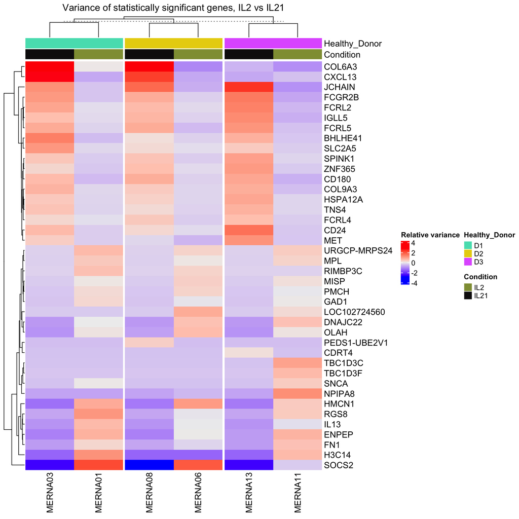

```r
topVarGenes <- order(rowVars(assay(vst)), decreasing = TRUE)
mat  <- assay(vst)[lfc.short.genes, ]
mat  <- mat - rowMeans(mat)
anno <- coldata
samples_of_interest <- anno$sample[anno$condition %in% c("IL21","IL2")]
anno <- anno[anno$condition %in% c("IL21","IL2"),]
anno <- droplevels(anno)
mat <- mat[,samples_of_interest]

column_ha = HeatmapAnnotation(Healthy_Donor = anno$healthy_donor,
                              Condition = anno$condition
                              )

Heatmap(mat,
        name = "Relative variance",
        column_title = "Variance of statistically significant genes, IL2 vs IL21",
        top_annotation = column_ha,
        cluster_columns = TRUE,
        column_split = anno$healthy_donor,
        cluster_rows = TRUE
        )
```

### LFC for each condition

```r
res.il21 <- results(dds,contrast = c("condition","UST","IL21"))
res.sig.il21 <- subset(res.il21, padj < 0.1)
lfc.il21 <- res.sig.il21[ order(res.sig.il21$log2FoldChange, decreasing=TRUE), ]
lfc.il21
```

```
## log2 fold change (MLE): condition UST vs IL21
## Wald test p-value: condition UST vs IL21
## DataFrame with 917 rows and 6 columns
##           baseMean log2FoldChange     lfcSE      stat      pvalue        padj
##          <numeric>      <numeric> <numeric> <numeric>   <numeric>   <numeric>
## NPIPA8    142.1690        24.4833   3.92826   6.23260 4.58769e-10 1.98770e-06
## TBC1D3C    38.2409        22.7845   4.68386   4.86447 1.14763e-06 2.37177e-04
## TBC1D3F    34.4205        22.6967   4.71282   4.81595 1.46498e-06 2.80500e-04
## IL13      119.9618        10.3007   1.85400   5.55591 2.76174e-08 1.89252e-05
## DNAJC22   102.3846        10.1212   1.74698   5.79352 6.89252e-09 8.45038e-06
## ...            ...            ...       ...       ...         ...         ...
## SLC1A7     12.8818       -8.09469   2.32189  -3.48626 4.89833e-04  0.01781689
## TENM4      15.8898       -8.24361   2.69018  -3.06433 2.18158e-03  0.04728920
## MMP7       12.4804       -8.32245   2.89859  -2.87120 4.08913e-03  0.07293211
## TMEM255A   17.8974       -8.66294   2.39517  -3.61683 2.98230e-04  0.01236611
## PRICKLE1   19.0254       -8.70749   2.14945  -4.05104 5.09909e-05  0.00330299
```

```r
res.il15 <- results(dds,contrast = c("condition","UST","IL15"))
res.sig.il15 <- subset(res.il15, padj < 0.1)
lfc.il15 <- res.sig.il15[ order(res.sig.il15$log2FoldChange, decreasing=TRUE), ]
lfc.il15
```

```
## log2 fold change (MLE): condition UST vs IL15
## Wald test p-value: condition UST vs IL15
## DataFrame with 2 rows and 6 columns
##               baseMean log2FoldChange     lfcSE      stat      pvalue
##              <numeric>      <numeric> <numeric> <numeric>   <numeric>
## LOC728392      32.5997        19.4137   3.68793   5.26412 1.40862e-07
## FAM47E-STBD1   16.9447        18.1392   3.58362   5.06169 4.15548e-07
##                    padj
##               <numeric>
## LOC728392    0.00190713
## FAM47E-STBD1 0.00281305
```

```r
res.il7 <- results(dds,contrast = c("condition","UST","IL7"))
res.sig.il7 <- subset(res.il7, padj < 0.1)
lfc.il7 <- res.sig.il7[ order(res.sig.il7$log2FoldChange, decreasing=TRUE), ]
lfc.il7
```

```
## log2 fold change (MLE): condition UST vs IL7
## Wald test p-value: condition UST vs IL7
## DataFrame with 3 rows and 6 columns
##          baseMean log2FoldChange     lfcSE      stat      pvalue        padj
##         <numeric>      <numeric> <numeric> <numeric>   <numeric>   <numeric>
## ALDH1A1   12.8403       20.88013  3.401942   6.13771 8.37203e-10 5.66744e-06
## FCN1      14.5380       20.29306  2.707439   7.49530 6.61477e-14 8.95573e-10
## ATP13A4  116.2755       -3.40627  0.654527  -5.20417 1.94869e-07 8.79444e-04
```

```r
res.il2 <- results(dds,contrast = c("condition","UST","IL2"))
res.sig.il2 <- subset(res.il2, padj < 0.1)
lfc.il2 <- res.sig.il2[ order(res.sig.il2$log2FoldChange, decreasing=TRUE), ]
lfc.il2
```

```
## log2 fold change (MLE): condition UST vs IL2
## Wald test p-value: condition UST vs IL2
## DataFrame with 2 rows and 6 columns
##               baseMean log2FoldChange     lfcSE      stat      pvalue
##              <numeric>      <numeric> <numeric> <numeric>   <numeric>
## PEDS1-UBE2V1   57.5161        23.4696   4.71238   4.98041 6.34508e-07
## CDRT4          40.4202        22.7108   3.82685   5.93459 2.94584e-09
##                     padj
##                <numeric>
## PEDS1-UBE2V1 4.29530e-03
## CDRT4        3.98838e-05
```

```r
## Data preparation
pval_threshold <- 0.1
il21.degs <- row.names(lfc.il21[which(lfc.il21$padj <= pval_threshold), ])
il15.degs <- row.names(lfc.il15[which(lfc.il15$padj <= pval_threshold), ])
il7.degs <- row.names(lfc.il7[which(lfc.il7$padj <= pval_threshold), ])
il2.degs <- row.names(lfc.il2[which(lfc.il2$padj <= pval_threshold), ])
list.degs <- paste(c(il15.degs,il7.degs,il2.degs))
list.degs <- unique(list.degs)
```

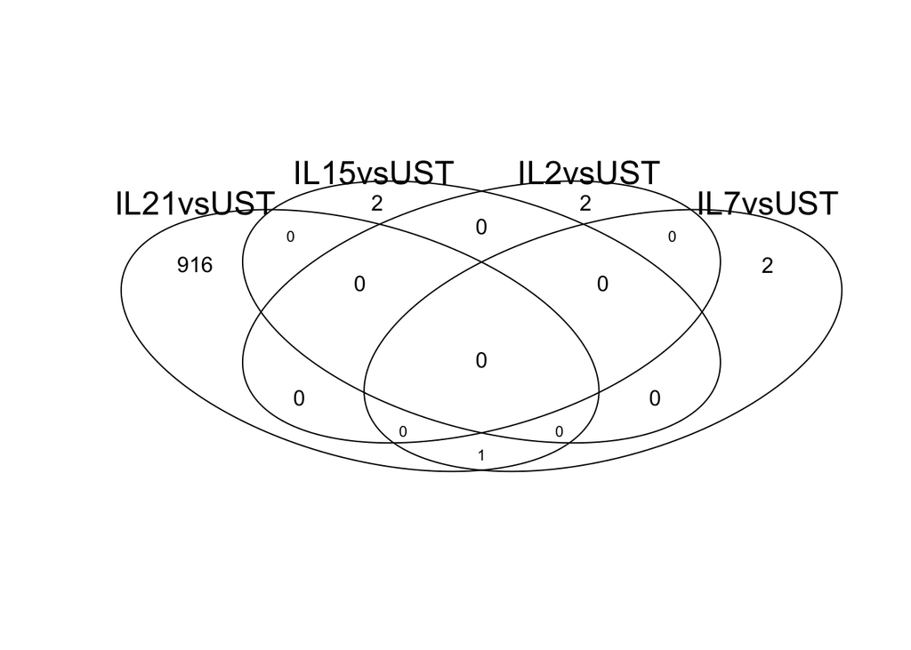

```r
## Alternative method using the `gplots` library
library(gplots)
# Create a Venn-diagram given just the list of gene-names for both sets
venn(list("IL21vsUST" = il21.degs,
          "IL15vsUST" = il15.degs,
          "IL2vsUST" = il2.degs,
          "IL7vsUST" = il7.degs), )
```

```r
res.il21 <- results(dds,contrast = c("condition","IL7","IL21"))
res.sig.il21 <- subset(res.il21, padj < 0.1)
lfc.il21 <- res.sig.il21[ order(res.sig.il21$log2FoldChange, decreasing=TRUE), ]
lfc.il21
```

```
## log2 fold change (MLE): condition IL7 vs IL21
## Wald test p-value: condition IL7 vs IL21
## DataFrame with 644 rows and 6 columns
##               baseMean log2FoldChange     lfcSE      stat      pvalue
##              <numeric>      <numeric> <numeric> <numeric>   <numeric>
## NPIPA8        142.1690       24.09323   3.92836   6.13315 8.61550e-10
## TBC1D3F        34.4205       21.90429   4.71356   4.64708 3.36672e-06
## TBC1D3C        38.2409       20.62071   4.68716   4.39940 1.08549e-05
## H3C14         300.9500       11.09638   1.90834   5.81467 6.07551e-09
## IL13          119.9618        9.74443   1.85437   5.25484 1.48155e-07
## ...                ...            ...       ...       ...         ...
## MMP7           12.4804       -8.34948   2.89859  -2.88053 3.97009e-03
## C8orf44-SGK3   20.2580       -8.54610   2.63999  -3.23717 1.20721e-03
## SSPN           17.4304       -8.65000   2.60777  -3.31701 9.09862e-04
## ALDH1A1        12.8403      -20.09156   3.40563  -5.89951 3.64586e-09
## FCN1           14.5380      -20.98590   2.70364  -7.76209 8.35428e-15
##                     padj
##                <numeric>
## NPIPA8       2.91613e-06
## TBC1D3F      8.76578e-04
## TBC1D3C      1.92590e-03
## H3C14        1.37094e-05
## IL13         1.05572e-04
## ...                  ...
## MMP7         9.00352e-02
## C8orf44-SGK3 4.44243e-02
## SSPN         3.68157e-02
## ALDH1A1      9.87225e-06
## FCN1         1.13109e-10
```

```r
res.il15 <- results(dds,contrast = c("condition","IL15","IL21"))
res.sig.il15 <- subset(res.il15, padj < 0.1)
lfc.il15 <- res.sig.il15[ order(res.sig.il15$log2FoldChange, decreasing=TRUE), ]
lfc.il15
```

```
## log2 fold change (MLE): condition IL15 vs IL21
## Wald test p-value: condition IL15 vs IL21
## DataFrame with 408 rows and 6 columns
##               baseMean log2FoldChange     lfcSE      stat      pvalue
##              <numeric>      <numeric> <numeric> <numeric>   <numeric>
## NPIPA8        142.1690       23.58892   3.92852   6.00453 1.91883e-09
## TBC1D3C        38.2409       22.07698   4.68445   4.71282 2.44308e-06
## TBC1D3F        34.4205       21.72688   4.71384   4.60917 4.04280e-06
## H3C14         300.9500       11.56571   1.90824   6.06092 1.35342e-09
## IL13          119.9618        9.28261   1.85496   5.00420 5.60934e-07
## ...                ...            ...       ...       ...         ...
## COL6A3        762.1209       -6.16000   1.20278  -5.12147 3.03159e-07
## NCAN           15.4746       -6.34453   1.78101  -3.56233 3.67583e-04
## CXCL13        170.1401      -11.00091   2.33547  -4.71037 2.47270e-06
## FAM47E-STBD1   16.9447      -18.67213   3.58115  -5.21401 1.84803e-07
## LOC728392      32.5997      -20.49003   3.68642  -5.55824 2.72503e-08
##                     padj
##                <numeric>
## NPIPA8       8.49276e-06
## TBC1D3C      1.09442e-03
## TBC1D3F      1.37642e-03
## H3C14        8.49276e-06
## IL13         5.28027e-04
## ...                  ...
## COL6A3       3.65941e-04
## NCAN         2.71154e-02
## CXCL13       1.09442e-03
## FAM47E-STBD1 3.00458e-04
## LOC728392    6.03049e-05
```

```r
res.il7 <- results(dds,contrast = c("condition","IL2","IL21"))
res.sig.il7 <- subset(res.il7, padj < 0.1)
lfc.il7 <- res.sig.il7[ order(res.sig.il7$log2FoldChange, decreasing=TRUE), ]
lfc.il7
```

```
## log2 fold change (MLE): condition IL2 vs IL21
## Wald test p-value: condition IL2 vs IL21
## DataFrame with 1003 rows and 6 columns
##               baseMean log2FoldChange     lfcSE      stat      pvalue
##              <numeric>      <numeric> <numeric> <numeric>   <numeric>
## NPIPA8        142.1690       23.36161   3.92866   5.94646 2.74006e-09
## TBC1D3C        38.2409       22.25217   4.68429   4.75038 2.03031e-06
## TBC1D3F        34.4205       21.37384   4.71440   4.53374 5.79486e-06
## H3C14         300.9500       11.02760   1.90837   5.77854 7.53525e-09
## RGS8           73.0691        9.71039   1.85609   5.23164 1.68009e-07
## ...                ...            ...       ...       ...         ...
## SLC2A5         19.1692       -6.29597   2.08394  -3.02118 2.51792e-03
## HSPA12A        12.2075       -8.22052   2.90436  -2.83041 4.64883e-03
## CXCL13        170.1401       -8.86933   2.11632  -4.19093 2.77817e-05
## CDRT4          40.4202      -19.62990   3.83627  -5.11692 3.10559e-07
## PEDS1-UBE2V1   57.5161      -20.67666   4.71594  -4.38442 1.16295e-05
##                     padj
##                <numeric>
## NPIPA8       6.73955e-06
## TBC1D3C      2.73256e-04
## TBC1D3F      6.13407e-04
## H3C14        8.91900e-06
## RGS8         5.33530e-05
## ...                  ...
## SLC2A5       5.08352e-02
## HSPA12A      7.25131e-02
## CXCL13       1.87817e-03
## CDRT4        8.75751e-05
## PEDS1-UBE2V1 1.00944e-03
```

Now have a list of multiple condition comparisons. The picture doesn’t appear to change regardless. I think the best comparison is IL2vsIL21, but I need to go through the notes to see if there is a better study design.

What I could have a look at is the venn diagram of IL21vs OTHER, and IL21vsIL2, and maybe focus on genes that just appear in IL21vsIL2

```r
## Data preparation
pval_threshold <- 0.1
il21.degs <- row.names(lfc.il21[which(lfc.il21$padj <= pval_threshold), ])
il15.degs <- row.names(lfc.il15[which(lfc.il15$padj <= pval_threshold), ])
il7.degs <- row.names(lfc.il7[which(lfc.il7$padj <= pval_threshold), ])
list.degs <- paste(c(il15.degs,il7.degs))
list.degs <- unique(list.degs)
length(list.degs)
```

```
## [1] 1051
```

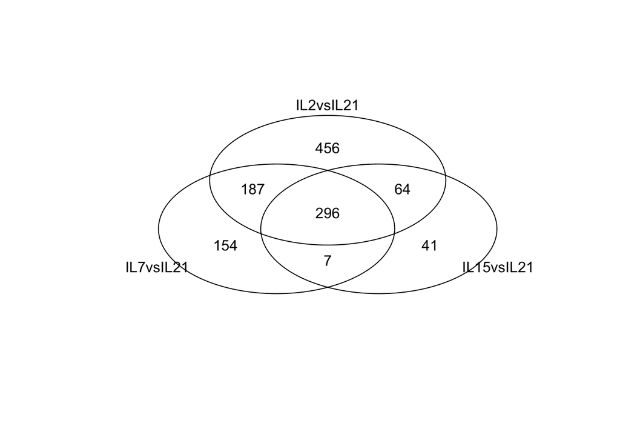

```r
## Alternative method using the `gplots` library
library(gplots)
# Create a Venn-diagram given just the list of gene-names for both sets
venn(list("IL7vsIL21" = il21.degs,
          "IL15vsIL21" = il15.degs,
          "IL2vsIL21" = il7.degs), )
```

```r
# Assuming il21.degs, il15.degs, and il7.degs are your lists of genes

# Create the lists
il21_genes <- il21.degs
il15_genes <- il15.degs
il7_genes <- il7.degs

# Extract genes in IL7vsUST that are not found in any other list
unique_IL7_genes <- setdiff(il7_genes, union(il21_genes, il15_genes))

common_genes <- Reduce(intersect, list(il21_genes, il15_genes, il7_genes))


# Print or use the unique genes as needed
length(unique_IL7_genes)
```

```
## [1] 456
```

```r
head(unique_IL7_genes)
```

```
## [1] "LOC102724560" "URGCP-MRPS24" "RIMBP3C"      "MISP"         "APC2"
## [6] "IQGAP3"
```

```r
length(common_genes)
```

```
## [1] 296
```

```r
head(common_genes)
```

```
## [1] "NPIPA8"  "TBC1D3F" "TBC1D3C" "H3C14"   "IL13"    "DNAJC22"
```

```r
resSig <- subset(res, padj < 0.05)
lfc <- resSig[ order(resSig$log2FoldChange, decreasing=TRUE), ]
lfc
```

```
## log2 fold change (MLE): condition IL2 vs IL21
## Wald test p-value: condition IL2 vs IL21
## DataFrame with 639 rows and 6 columns
##               baseMean log2FoldChange     lfcSE      stat      pvalue
##              <numeric>      <numeric> <numeric> <numeric>   <numeric>
## NPIPA8        142.1690       23.36161   3.92866   5.94646 2.74006e-09
## TBC1D3C        38.2409       22.25217   4.68429   4.75038 2.03031e-06
## TBC1D3F        34.4205       21.37384   4.71440   4.53374 5.79486e-06
## H3C14         300.9500       11.02760   1.90837   5.77854 7.53525e-09
## RGS8           73.0691        9.71039   1.85609   5.23164 1.68009e-07
## ...                ...            ...       ...       ...         ...
## SPINK1         33.2139       -5.20844   1.67036  -3.11815 1.81988e-03
## FCGR2B         85.2695       -5.33515   1.31129  -4.06863 4.72901e-05
## CXCL13        170.1401       -8.86933   2.11632  -4.19093 2.77817e-05
## CDRT4          40.4202      -19.62990   3.83627  -5.11692 3.10559e-07
## PEDS1-UBE2V1   57.5161      -20.67666   4.71594  -4.38442 1.16295e-05
##                     padj
##                <numeric>
## NPIPA8       6.73955e-06
## TBC1D3C      2.73256e-04
## TBC1D3F      6.13407e-04
## H3C14        8.91900e-06
## RGS8         5.33530e-05
## ...                  ...
## SPINK1       4.07829e-02
## FCGR2B       2.83741e-03
## CXCL13       1.87817e-03
## CDRT4        8.75751e-05
## PEDS1-UBE2V1 1.00944e-03
```

```r
lfc.df <- as.data.frame(lfc)
lfc.df <- lfc.df[which(rownames(lfc.df) %in% common_genes),]
lfc.head <- head(lfc.df, n=20)
lfc.tail <- tail(lfc.df, n=20)
lfc.short <- rbind(lfc.head,lfc.tail)
lfc.short
```

```
##              baseMean log2FoldChange     lfcSE      stat       pvalue
## NPIPA8      142.16896     23.3616085 3.9286593  5.946458 2.740065e-09
## TBC1D3C      38.24088     22.2521726 4.6842899  4.750383 2.030314e-06
## TBC1D3F      34.42051     21.3738447 4.7143968  4.533739 5.794861e-06
## H3C14       300.95001     11.0276010 1.9083722  5.778538 7.535254e-09
## RGS8         73.06914      9.7103923 1.8560879  5.231645 1.680086e-07
## DNAJC22     102.38463      9.4853395 1.7475211  5.427883 5.702652e-08
## HMCN1       250.03119      9.3296908 1.4929590  6.249127 4.127520e-10
## IL13        119.96183      9.2635105 1.8548650  4.994170 5.908946e-07
## FN1         100.16263      8.1015370 1.8192211  4.453300 8.456055e-06
## OLAH        103.54835      7.5978975 1.4951083  5.081838 3.738011e-07
## SNCA         22.98892      7.0447809 2.0134809  3.498807 4.673447e-04
## SOCS2      3035.45870      6.7030245 1.3361454  5.016688 5.256989e-07
## ENPEP       215.55524      6.6559768 1.8430122  3.611466 3.044705e-04
## GAD1         18.57450      6.6542228 1.8276804  3.640802 2.717900e-04
## HSPA4L       64.98304      6.5629843 1.3676898  4.798591 1.597857e-06
## OSBPL6       10.70025      6.5312464 1.6835335  3.879487 1.046770e-04
## APBA1        35.78626      6.3057944 1.7559875  3.591025 3.293806e-04
## KIF17        15.01273      6.2584013 1.8973666  3.298467 9.721429e-04
## MYLK2        15.88858      6.1234800 1.8903976  3.239255 1.198424e-03
## PAK3         17.20848      5.9394718 1.9490577  3.047356 2.308645e-03
## PDE4D     15424.50505      0.6279272 0.1494637  4.201203 2.655000e-05
## ORAI1      4013.44014      0.6243366 0.1707128  3.657234 2.549518e-04
## ST3GAL1   10803.69506      0.3222989 0.1037559  3.106319 1.894324e-03
## PTGR3      1719.29334     -0.6263426 0.1723784 -3.633532 2.795676e-04
## KLF10      2617.30289     -0.8597317 0.2095128 -4.103481 4.069801e-05
## MAGED2     3401.91080     -0.9232713 0.2142257 -4.309807 1.633974e-05
## SOX13       537.71292     -1.0964075 0.3099774 -3.537056 4.046138e-04
## CPEB2       734.32060     -1.1892318 0.3165089 -3.757340 1.717289e-04
## BTBD8       329.83534     -1.4056161 0.3827256 -3.672647 2.400513e-04
## ACVR1       501.28833     -1.6262337 0.4252462 -3.824217 1.311883e-04
## RAB11FIP5  1222.97720     -1.6425020 0.3937728 -4.171192 3.030105e-05
## RUBCNL      573.17583     -2.3094062 0.5986073 -3.857966 1.143348e-04
## MERTK       129.85103     -2.3503862 0.7201017 -3.263964 1.098650e-03
## ZC3H12D     883.23648     -2.4819855 0.6794097 -3.653150 2.590427e-04
## DTX1        421.25080     -3.5032323 0.8373456 -4.183735 2.867581e-05
## BCAT1      2739.75375     -3.7023653 0.9090945 -4.072586 4.649409e-05
## ENPP2        36.56641     -4.0009952 0.9758146 -4.100159 4.128658e-05
## TNFRSF8     825.53759     -4.0829190 1.1944507 -3.418240 6.302756e-04
## COL6A3      762.12092     -4.5287597 1.1971949 -3.782809 1.550684e-04
```

[output cut: 27 more lines]

```
## MAGED2    1.273913e-03
## SOX13     1.393670e-02
## CPEB2     7.403675e-03
## BTBD8     9.499904e-03
## ACVR1     6.211170e-03
## RAB11FIP5 2.012856e-03
## RUBCNL    5.472937e-03
## MERTK     2.866617e-02
## ZC3H12D   1.003790e-02
## DTX1      1.924531e-03
## BCAT1     2.802560e-03
## ENPP2     2.535620e-03
## TNFRSF8   1.917334e-02
## COL6A3    6.986128e-03
## JCHAIN    2.443373e-05
```

```r
#lfc.short <- lfc.head
lfc.short$names <- rownames(lfc.short)
lfc.short.genes <- rownames(lfc.short)

# lfc.short$desc <- mapIds(org.Hs.eg.db,lfc.short.genes,keytype = "SYMBOL",column="GENETYPE")
# keytypes(org.Hs.eg.db)
```

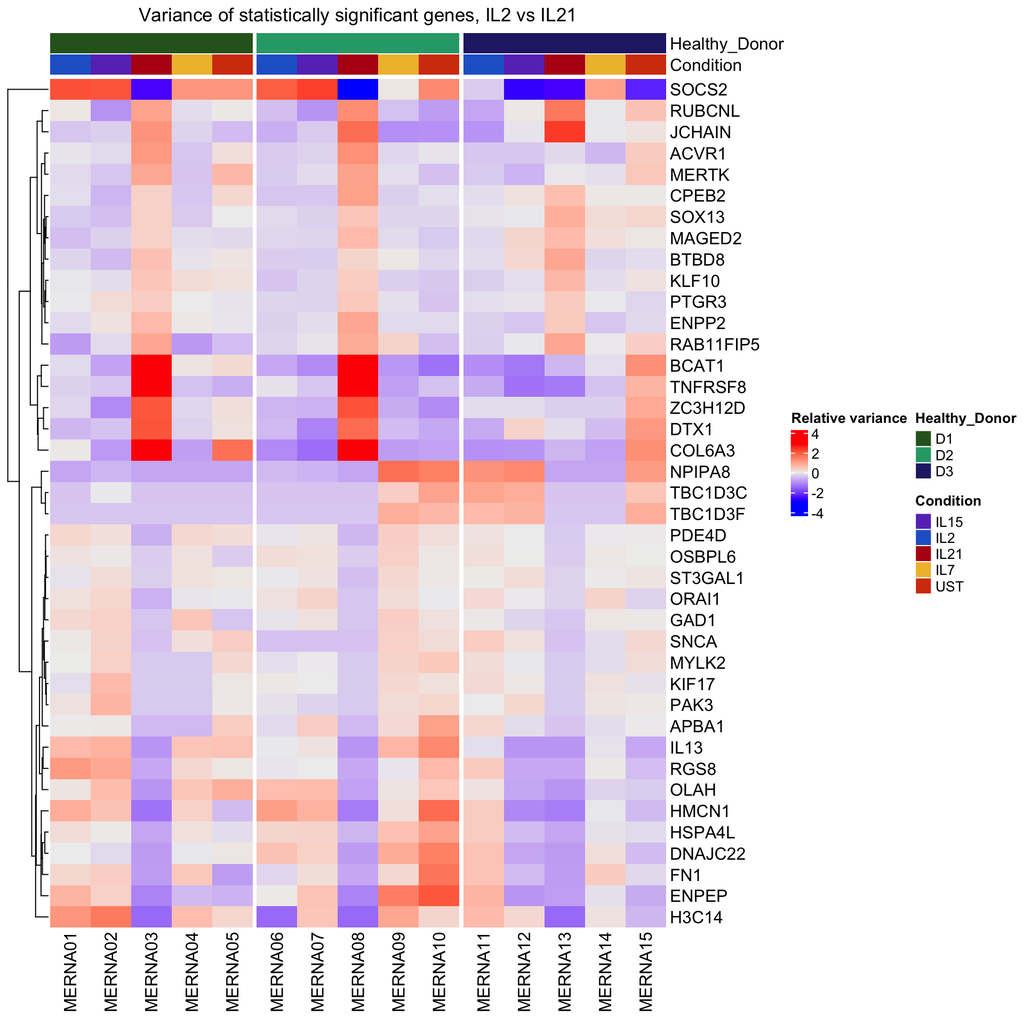

```r
topVarGenes <- order(rowVars(assay(vst)), decreasing = TRUE)
mat  <- assay(vst)[lfc.short.genes, ]
mat  <- mat - rowMeans(mat)
anno <- coldata
# samples_of_interest <- anno$sample[anno$condition %in% c("IL21","IL2")]
# anno <- anno[anno$condition %in% c("IL21","IL2"),]
# anno <- droplevels(anno)
# mat <- mat[,samples_of_interest]

column_ha = HeatmapAnnotation(Healthy_Donor = anno$healthy_donor,
                              Condition = anno$condition
                              )

Heatmap(mat,
        name = "Relative variance",
        column_title = "Variance of statistically significant genes, IL2 vs IL21",
        top_annotation = column_ha,
        cluster_columns = F,
        column_split = anno$healthy_donor,
        cluster_rows = TRUE
        )
```